# Distributions

2022-09-20

## Distributions and Summary Statistics

## Variable types

- categorical data
- ordinal
- numerical: Some numerical data can be treated as ordered categorical.
  - continuous or discrete

## Distributions

```r
prop.table(table(state.region))
```

```
#> state.region
#>     Northeast         South North Central          West
#>          0.18          0.32          0.24          0.26
```

## Case study: describing student heights

```r
library(tidyverse)
library(dslabs)
data(heights)
```

## Empirical cumulative distribution functions

- Statistics textbooks teach us that a more useful way to define a distribution for numeric data is to define a function that reports the proportion of the data entries \(x\) that are below \(a\), for all possible values of \(a\).

## Empirical cumulative distribution functions

- This function is called the empirical cumulative distribution function (eCDF) and often denoted with \(F\):

\[ F(a) = \mbox{Proportion of data points that are less than or equal to }a\]

## Empirical cumulative distribution functions

Here is a plot of \(F\) for the male height data:

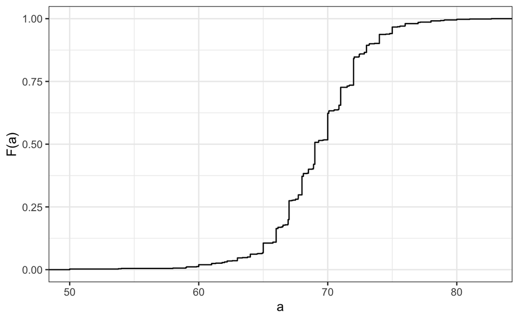

## Empirical cumulative distribution functions

- Similar to what the frequency table does for categorical data, the eCDF defines the distribution for numerical data. From the plot, we can see that 16% of the values are below 65, since \(F(66)=\) 0.164, or that 84% of the values are below 72, since \(F(72)=\) 0.841, and so on.

## Histograms

Here is the histogram for the height data splitting the range of values into one inch intervals: \((49.5, 50.5],(50.5, 51.5],(51.5,52.5],(52.5,53.5],...,(82.5,83.5]\)

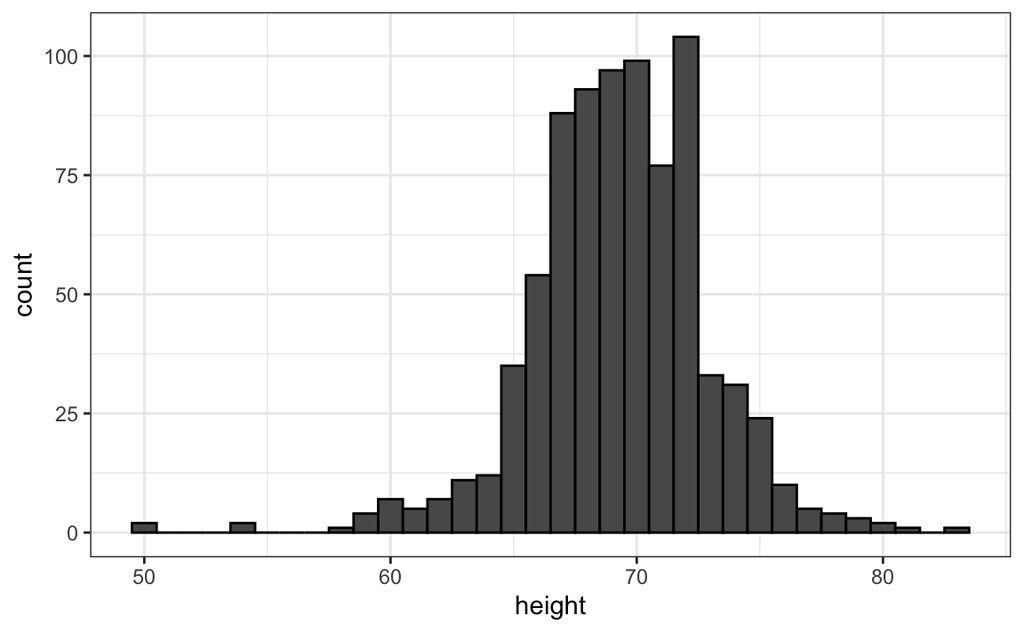

## Histograms

If we send this plot as a summary , we will immediately learn some important properties about our data.

1. The range of the data is from 50 to 84 with the majority (more than 95%) between 63 and 75 inches.
2. The heights are close to symmetric around 69 inches.

By adding up counts, we could obtain a very good approximation of the proportion of the data in any interval.

But, what information do we lose?

## Smoothed density

Smooth density plots are similar to histograms, but the data is not divided into bins. Here is what a smooth density plot looks like for our heights data:

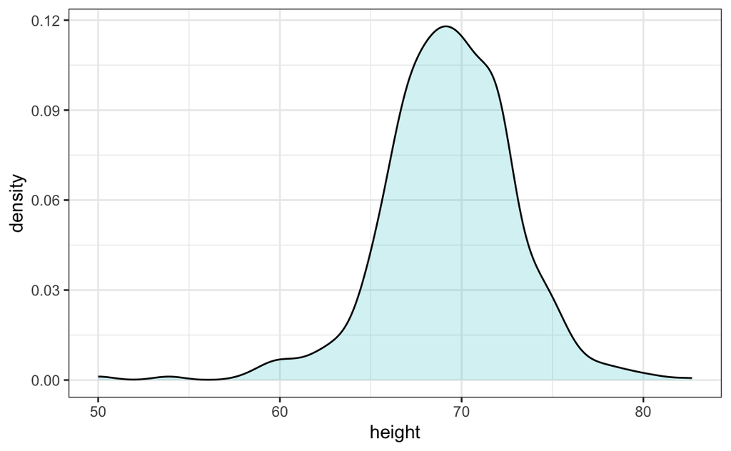

## Smoothed density

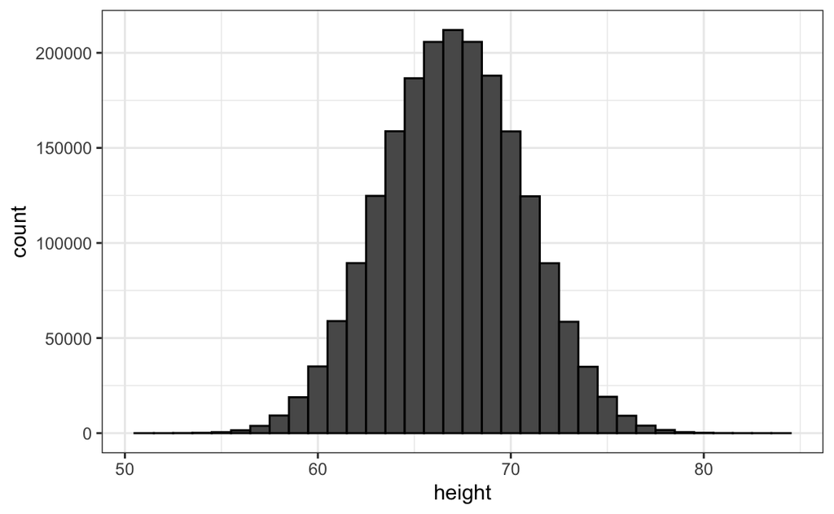

## Smoothed density

The smaller we make the bins, the smoother the histogram gets. Here are the histograms with bin width of 1, 0.5, and 0.1:

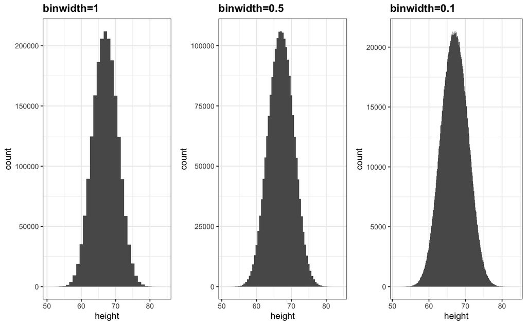

## Smoothed density

The smooth density is basically the curve that goes through the top of the histogram bars when the bins are very, very small. :

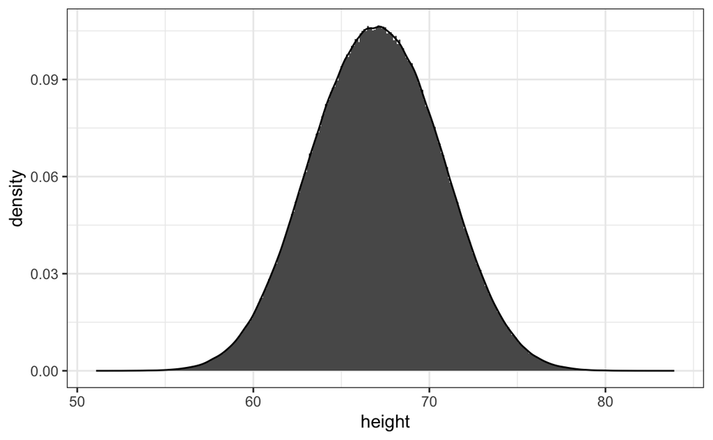

To make the curve not depend on the hypothetical size of the hypothetical list, we compute the curve on frequencies rather than counts.

## Smoothed density

Now, back to reality. We don’t have millions of measurements. Instead, we have 812 and we can’t make a histogram with very small bins.

We therefore make a histogram, using bin sizes appropriate for our data and computing frequencies rather than counts, and we draw a smooth curve that goes through the tops of the histogram bars.

## Smoothed density

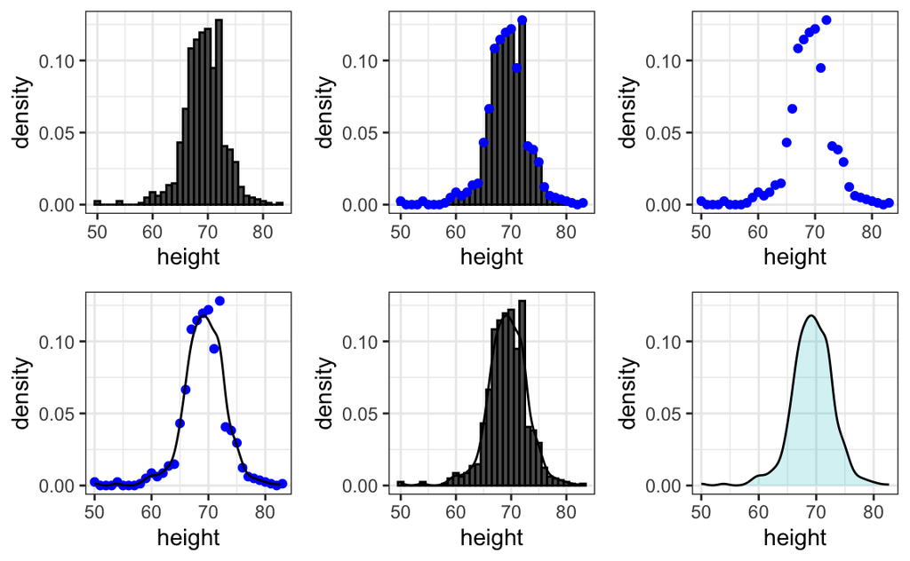

## Smoothed density

However, remember that *smooth* is a relative term. We can actually control the *smoothness* of the curve that defines the smooth density through an option in the function that computes the smooth density curve.

## Smoothed density

Here are two examples using different degrees of smoothness on the same histogram:

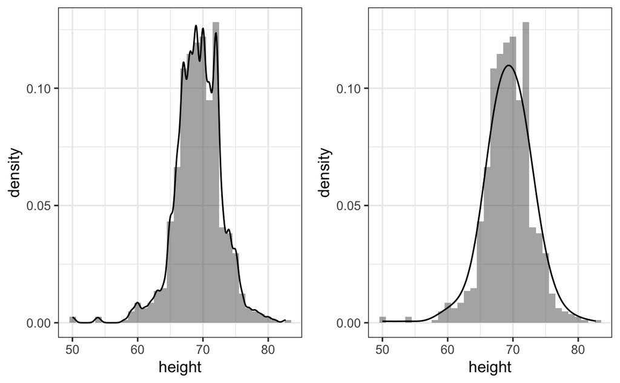

## Smoothed density

& We need to make this choice with care as the resulting summary can change our interpretation of the data. We should select a degree of smoothness that we can defend as being representative of the underlying data.

- While the histogram is an assumption-free summary, the smoothed density is based on some assumptions.
- Note that interpreting the y-axis of a smooth density plot is not straightforward. It is scaled so that the area under the density curve adds up to 1.

## Smoothed density

The proportion of this area is about 0.3, meaning that about 30% of male heights are between 65 and 68 inches.

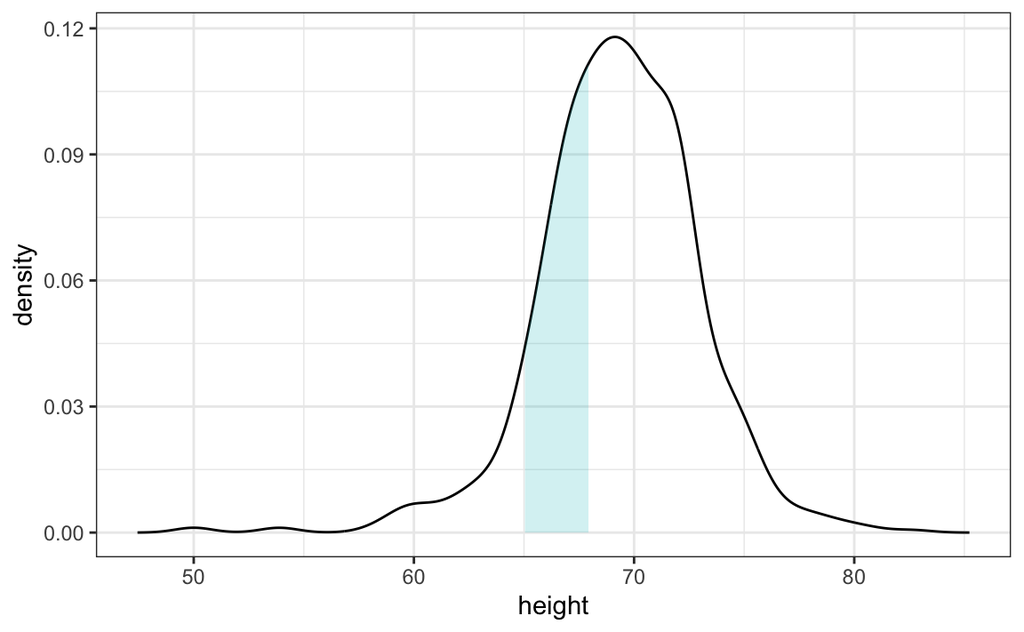

## Smoothed density

By understanding this, we are ready to use the smooth density as a summary. For this dataset, we would feel quite comfortable with the smoothness assumption, and therefore with sharing an aesthetically pleasing figure, which he could use to understand our male heights data.

## Smoothed density

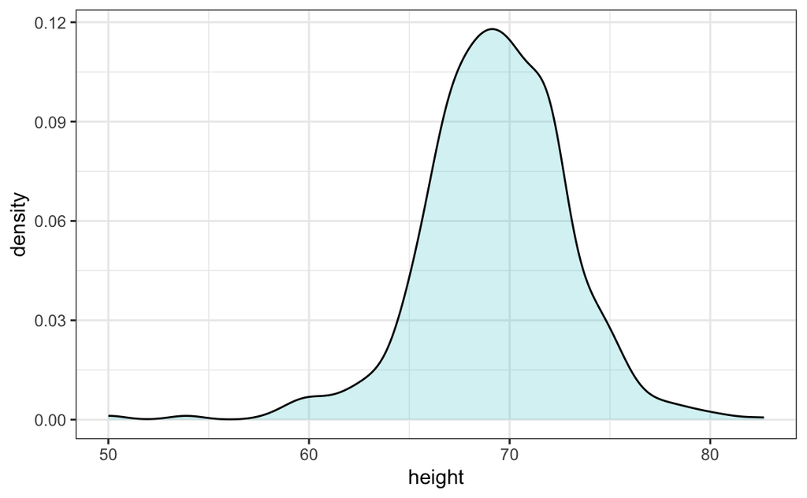

## Break for exercises

## The normal distribution

\[\mbox{Pr}(a < x \leq b) = \int_a^b \frac{1}{\sqrt{2\pi}s} e^{-\frac{1}{2}\left( \frac{x-m}{s} \right)^2} \, dx\]

- Note that it is completely defined by just two parameters: \(m\) and \(s\), refered to as average and standard deviation.
- The distribution is symmetric, centered at the average
- Most values (about 95%) are within 2 SDs from the average.

## The normal distribution

Here is what the normal distribution looks like when the average is 0 and the SD is 1:

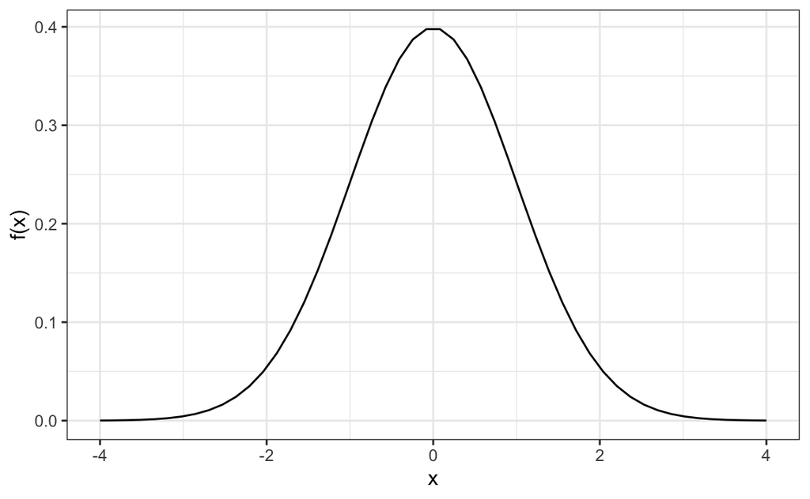

## The normal distribution

- The fact that the distribution is defined by just two parameters implies that if a dataset is approximated by a normal distribution, all the information needed to describe the distribution can be encoded in just two numbers:
- the average \(m\) and
- the standard deviation \(s\).

## The normal distribution

For a list of numbers contained in a vector `x`, the average is defined as:

```r
m <- sum(x) / length(x)
```

and the SD is defined as:

```r
s <- sqrt(sum((x-mu)^2) / length(x))
```

which can be interpreted as the average distance between values and their average.

## The normal distribution

Let’s compute the values for the height for males which we will store in the object \(x\):

```r
index <- heights$sex == "Male"
x <- heights$height[index]
```

## The normal distribution

The pre-built functions `mean` and `sd` can be used here:

```r
m <- mean(x)
s <- sd(x)
c(average = m, sd = s)
```

```
#> average      sd
#>   69.31    3.61
```

## The normal distribution

Advacned note: for reasons explained in statistics textbooks, the function `sd` is an estimate of an SD rather than an SD, defined by

```r
s <- sqrt(sum((x-mu)^2) / (length(x) - 1))
```

Note it divides by `length(x)-1` rather than `length(x)`.

But `sd(x)` and `sqrt(sum((x-mu)^2) / length(x))` are are practically equal when `length(x)` is large, so we often use `sd(x)` when we really want `sqrt(sum((x-mu)^2) / length(x))`.

## Example

Here is a plot of the smooth density of male heights in blue and the normal distribution with mean = 69.3 and SD = 3.6 plotted as a black curve:

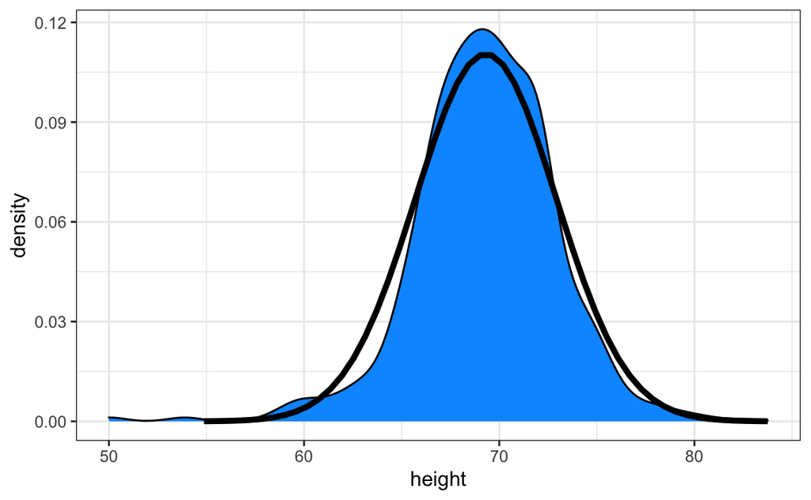

## Standard units

- Standard units for a vector `x` is defined as the nnumber of SDs `(x - mean(x)) / sd(x)`.
- It tells us, for each entry of `x`, how many SDs away from the average it is.
- Look back at the formula for the normal distribution and note that what is being exponentiated is \(-z^2/2\) with \(z\) equivalent to \(x\) in standard units.
- Because the maximum of \(e^{-z^2/2}\) is when \(z=0\), this explains why the maximum of the distribution occurs at the average. It also explains the symmetry since \(- z^2\) is symmetric around 0.

## Standard units

- Second, note that if we convert the normally distributed data to standard units, we can quickly know if, for example,
  - a person is about average (\(z \approx 0\)),
  - one of the largest (\(z \approx 2\)),
  - one of the smallest (\(z \approx -2\)),
  - or an extremely rare occurrence (\(z > 3\) or \(z < -3\)).
- Remember that it does not matter what the original units are, these rules apply to any data that is approximately normal.

## Standard units

In R, we can obtain standard units using the function `scale`:

```r
z <- scale(x)
```

## Standard units

Now to see how many men are within 2 SDs from the average, we simply type:

```r
mean(abs(z) < 2)
```

```
#> [1] 0.95
```

The proportion is about 95%, which is what the normal distribution predicts! To further confirm that, in fact, the approximation is a good one, we can use quantile-quantile plots.

## Quantile-quantile plots

- First let’s define the theoretical quantiles for the normal distribution.
- In statistics books we use the symbol \(\Phi(x)\) to define the function that gives us the proportion of a standard normal distributed data that are smaller than \(x\).
- So, for example, since 95% are between 2 and 2, \(\Phi(-2) \approx 0.025\) and \(\Phi(2) \approx 0.975\).
- In R, we can evaluate \(\Phi\) using the `pnorm` function:

```r
pnorm(-2)
```

```
#> [1] 0.0228
```

- Note: To get exactly 0.95 we use `pnorm(-1.96)`

## Quantile-quantile plots

- The inverse function \(\Phi^{-1}(x)\) gives us the *theoretical quantiles* for the normal distribution.
- So, for example, \(\Phi^{-1}(0.975) = 1.96\).
- In R, we can evaluate the inverse of \(\Phi\) using the `qnorm` function.

```r
qnorm(0.975)
```

```
#> [1] 1.96
```

## Quantile-quantile plots

- Note that these calculations are for the standard normal distribution by default (mean = 0, standard deviation = 1),
- but we can also define these for any normal distribution.

```r
qnorm(0.975, mean = 5, sd = 2)
```

```
#> [1] 8.92
```

## Quantile-quantile plots

- For the normal distribution, all the calculations related to quantiles are done without data, thus the name *theoretical quantiles*.
- But quantiles can be defined for any distribution, including an empirical one.
- So if we have data in a vector \(x\), we can define the quantile associated with any proportion \(p\) as the \(q\) for which the proportion of values below \(q\) is \(p\).

## Quantile-quantile plots

- We can define `q` as the value for which `mean(x <= q) = p`
- Notice that not all \(p\) have a \(q\) for which the proportion is exactly \(p\).
- There are several ways of defining the best \(q\) as discussed in the help for the `quantile` function.

## Quantile-quantile plots

To give a quick example, for the male heights data, we have that:

```r
mean(x <= 69.5)
```

```
#> [1] 0.515
```

So about 50% are shorter or equal to 69.5 inches. This implies that if \(p=0.50\) then \(q=69.5\).

## Quantile-quantile plots

- The idea of a QQ-plot is that if your data is well approximated by normal distribution then the quantiles of your data should be similar to the quantiles of a normal distribution.

## Quantile-quantile plots

To construct a QQ-plot, we do the following:

1. Define a vector of \(m\) proportions \(p_1, p_2, \dots, p_m\).
2. Define a vector of quantiles \(q_1, \dots, q_m\) for your data for the proportions \(p_1, \dots, p_m\). We refer to these as the *sample quantiles*.
3. Define a vector of theoretical quantiles for the proportions \(p_1, \dots, p_m\) for a normal distribution with the same average and standard deviation as the data.
4. Plot the sample quantiles versus the theoretical quantiles.

## Quantile-quantile plots

Let’s construct a QQ-plot using R code. Start by defining the vector of proportions.

```r
p <- seq(0.05, 0.95, 0.05)
```

## Quantile-quantile plots

To obtain the quantiles from the data, we can use the `quantile` function like this:

```r
sample_quantiles <- quantile(x, p)
```

## Quantile-quantile plots

To obtain the theoretical normal distribution quantiles with the corresponding average and SD, we use the `qnorm` function:

```r
theoretical_quantiles <- qnorm(p, mean = mean(x), sd = sd(x))
```

## Quantile-quantile plots

To see if they match or not, we plot them against each other and draw the identity line:

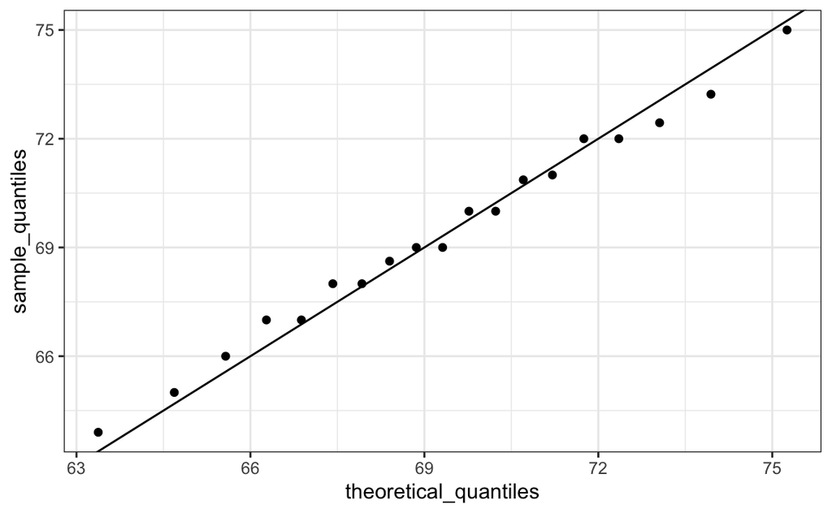

```r
qplot(theoretical_quantiles, sample_quantiles) + geom_abline()
```

## Quantile-quantile plots

Notice that this code becomes much cleaner if we use standard units:

```r
z <- scale(x)
sample_quantiles <- quantile(z, p)
theoretical_quantiles <- qnorm(p)
qplot(theoretical_quantiles, sample_quantiles) + geom_abline()
```

## Quantile-quantile plots

The code we just showed is included to help describe QQ-plots.

However, in practice it is easier to use **ggplot2** code:

```r
heights |> filter(sex == "Male") |>
  ggplot(aes(sample = scale(height))) +
  geom_qq() +
  geom_abline()
```

## Quantile-quantile plots

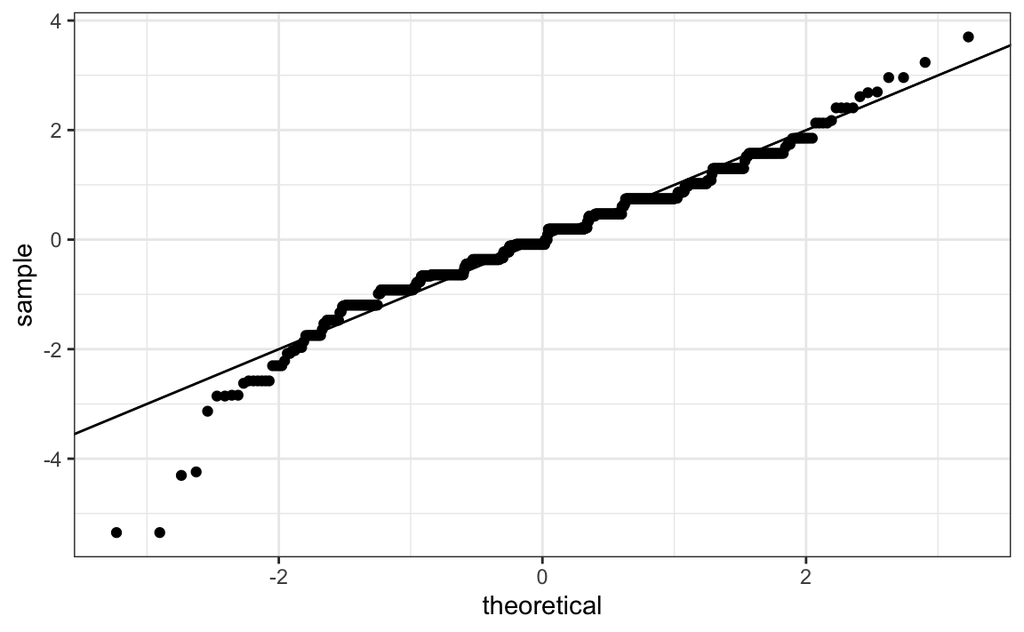

## Quantile-quantile plots

Note that although here we used qqplots to compare an observed distribution to the mathamatically defeine normal distribution, QQ-plots can be used to compare any two distributions.

## Percentiles

- Before we move on, let’s define some terms that are commonly used in exploratory data analysis.
- The percentiles are the quantiles you obtain when setting the \(p\) at \(0.01, 0.02, ..., 0.99\).
- We call, for example, the case of \(p=0.25\) the 25th percentile, which gives us a number for which 25% of the data is below. The most famous percentile is the 50th, also known as the *median*.

## Percentiles

For the normal distribution the *median* and average are the same, but this is generally not the case.

Another special case that receives a name are the *quartiles*, which are obtained when setting \(p=0.25,0.50\), and \(0.75\).

## Boxplots

- Suppose those used to receiving just two numbers as summaries ask us for a more compact numerical summary, rather than histogram or smooth density.
- The boxplot provides a five-number summary composed of the range along with the quartiles (the 25th, 50th, and 75th percentiles).

## Boxplots

The US state murder rates are an example of a variable that does not follow a normal distribution:

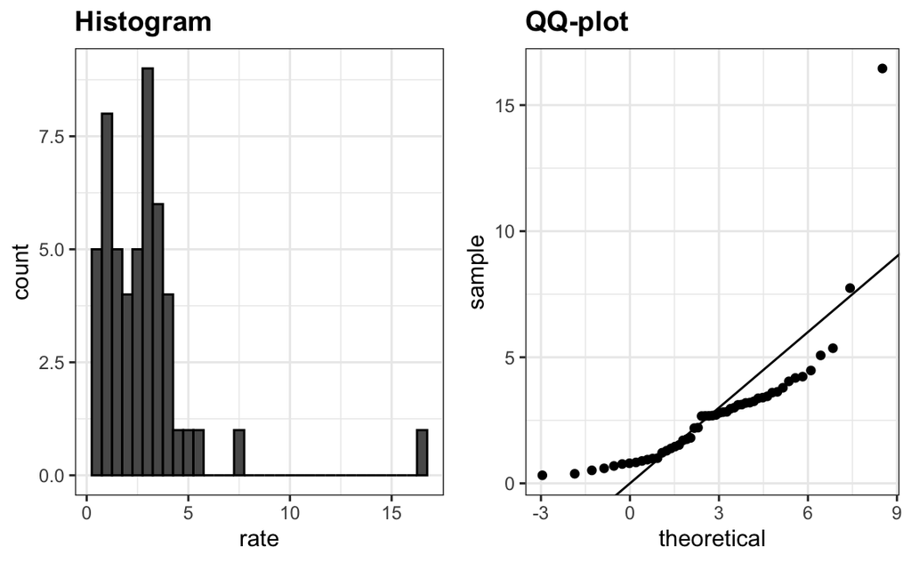

## Boxplots

While the average and SD two number summary is not useful, the 5 number boxplot tells use quite a bit:

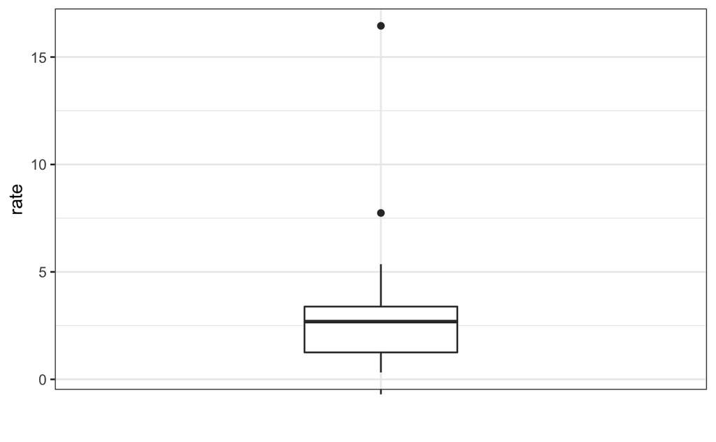

## Stratification

- In data analysis we often divide observations into groups based on the values of one or more variables associated with those observations.
- We call this procedure *stratification* and refer to the resulting groups as *strata*.

## Stratification

- Stratification is common in data visualization because we are often interested in how the distributions of variables differ across different subgroups.
- We will see several examples in the homework are future lectures.

## Case study: describing student heights

Here is an example with student heights:

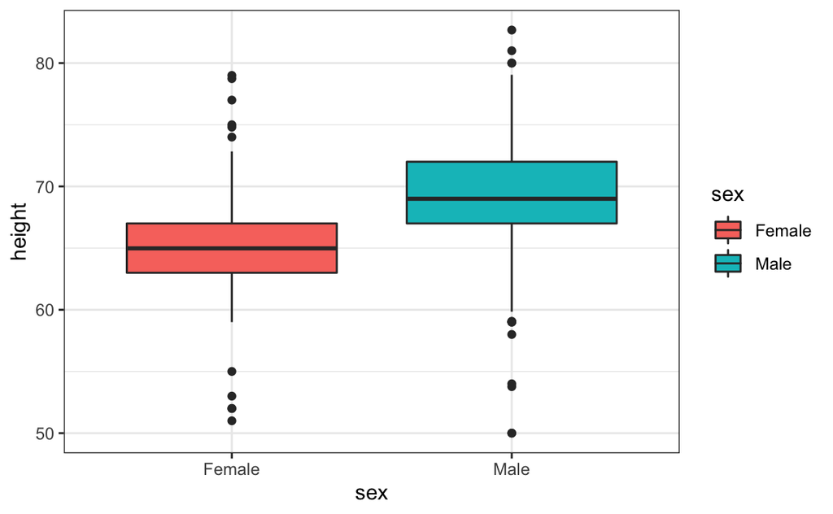

## Case study: describing student heights

- We saw that the normal approximation worked well for the male heights in our dataset.
- Now we see if it works for the female heights in our dataset.
- Our first exploratory plots reveal that the approximation is not as useful:

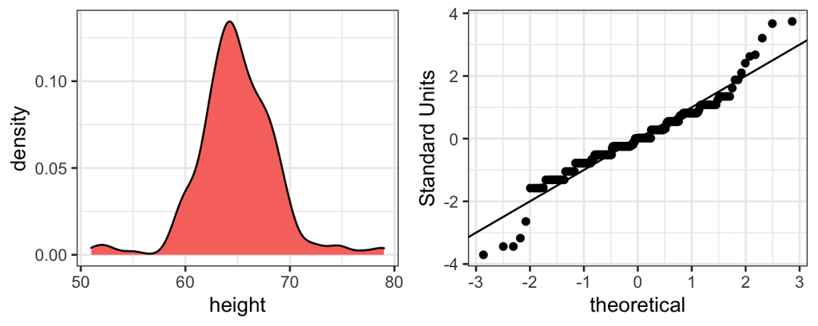

## Case study: describing student heights

- We see something we did not see for the males: the density plot has a second *bump*.
- Also, the QQ-plot shows that the highest points tend to be taller than expected by the normal distribution.
- Finally, we also see five points in the QQ-plot that suggest shorter than expected heights for a normal distribution.

## Case study: describing student heights

Regarding the five smallest values, note that these values are:

```r
heights |> filter(sex == "Female") |>
  top_n(5, desc(height)) |>
  pull(height)
```

```
#> [1] 51 53 55 52 52
```

Because these are reported heights, a possibility is that the student meant to enter `5'1"`, `5'2"`, `5'3"` or `5'5"`.